# Final Project

### 2. Learning rate and optimization method

Tune the optimization algorithm (try SGD with momentum and Adam) and the learning rate (try values between 0.0005-1, try no more than five values).

```python
# set ycn=True when you call experiments.run_experiment(...).
# Use meaningful names!
# ====== YOUR CODE: ======
experiments.run_experiment(f'adam_lr_1e-3',
                               seed=seed,
                               bs_train=50,
                               batches=10000,
                               epochs=30,
                               early_stopping=5,
                               reg=0,
                               lr=1e-3,
                               filters_per_layer=[32],
                               layers_per_block=4,
                               pool_every=2,
                               hidden_dims=[200, 200],
                               ycn=True)
# ========================
```

[output not shown]

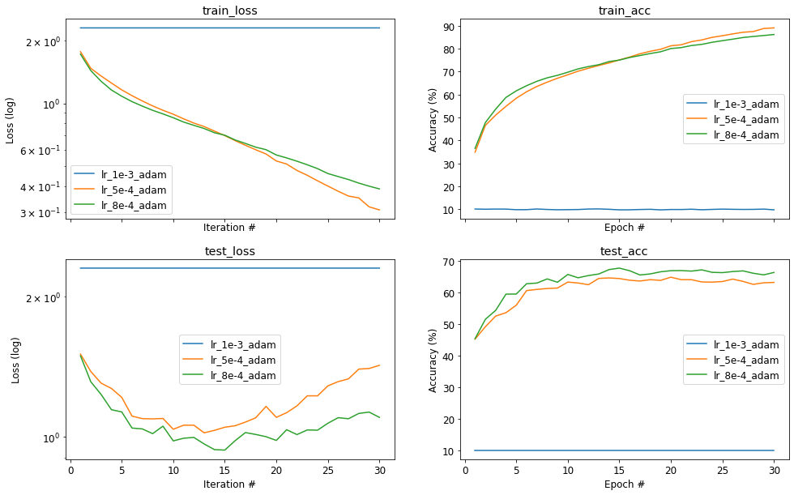

```python
plot_exp_results('exp1*.json') # plot your experiments results
```

**Answer in your Report:** Why should we add the momentum to SGD? What is the main two improvments adam has comparing to the simple SGD? What was the best optimization algorithm and best learning rate you've found?

Summarize this section results in your report.

**Note** - you will need to change the optimization used in experiments.run_experiment(...).

### 3. Add Batch Normalization

Add batch normalization to your network. You may want to read this blog before: https://www.baeldung.com/cs/batch-normalization-cnn

```python
# set ycn=True when you call experiments.run_experiment(...)
# Use meaningful names!
# ====== YOUR CODE: ======
experiments.run_experiment(f'batch_norm_lr_3e-3',
                               seed=seed,
                               bs_train=50,
                               batches=10000,
                               epochs=30,
                               early_stopping=4,
                               reg=0,
                               lr=1e-3,
                               filters_per_layer=[32],
                               layers_per_block=4,
                               pool_every=2,
                               hidden_dims=[200, 200],
                               ycn=True)
# ========================
```

[output not shown]

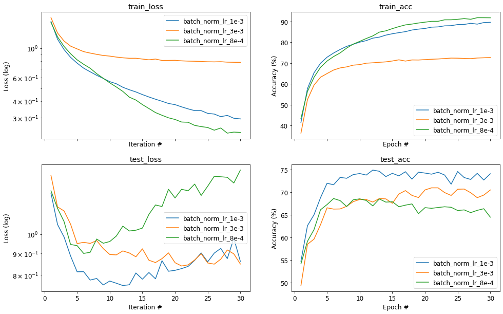

```python
plot_exp_results('exp2*.json') # plot your experiments results
```

**Answer in your Report:** What is the purpose of batch normalization (why do we use it)? Did the Batch normalization improve the network preformance? Summeraize this section results in your report.

### 4. Regularization

Try to add regularization to your optimization. In particular add L2, l1 regularization (read about weight_decay in adam) and dropout layer to your network (try them separately).

```python
# set ycn=True when you call experiments.run_experiment(...)
# Use meaningful names!
# ====== YOUR CODE: ======
experiments.run_experiment(f'exp3',
                               seed=seed,
                               bs_train=50,
                               batches=10000,
                               epochs=30,
                               early_stopping=4,
                               reg=1e-3,
                               lr=1e-3,
                               filters_per_layer=[128],
                               layers_per_block=4,
                               pool_every=2,
                               hidden_dims=[200, 200],
                               ycn=True)
# ========================
```

[output not shown]

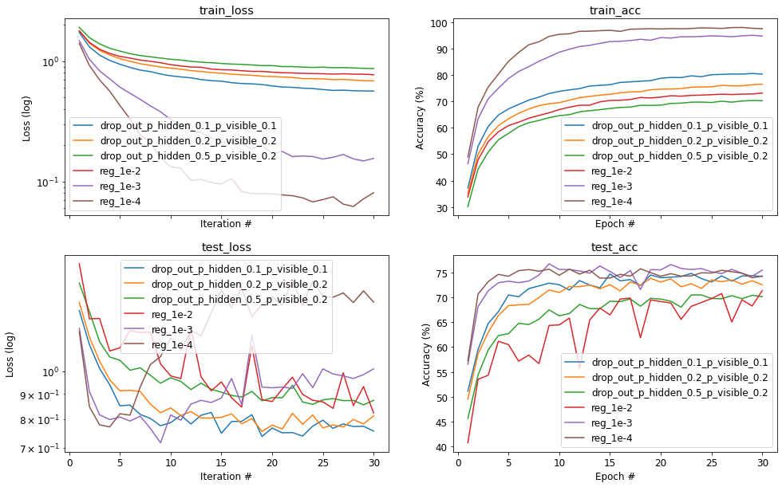

```python
plot_exp_results('exp3*.json') # plot your experiments results
```

**Answer in your Report:** Why should we use regularization? How does the regularization affect the train accuracy and loss? How does it affect the val and test accuracy and loss? What was the best regulrization method? Summarize this section results in your report.

### 5.Use Data Augmentation

Now try data augmentation. Take a look at pytorch tutorial: https://pytorch.org/vision/stable/transforms.html

```python
# set ycn=True when you call experiments.run_experiment(...)
# Use meaningful names!
# ====== YOUR CODE: ======
experiments.run_experiment(f'exp4',
                               seed=seed,
                               bs_train=50,
                               batches=10000,
                               epochs=30,
                               early_stopping=4,
                               reg=1e-3,
                               lr=1e-3,
                               filters_per_layer=[128],
                               layers_per_block=4,
                               pool_every=2,
                               hidden_dims=[200, 200],
                               ycn=True)
# ========================
```

[output not shown]

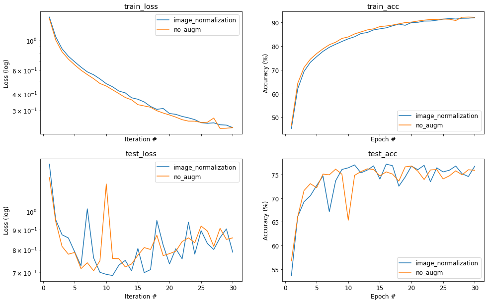

```python
plot_exp_results('exp4*.json') # plot your experiments results
```

**Answer in your Report:** Did the data augmentation improve the model preformace? Mention which augmentation you used and why.

## Summary Up To Here

**Answer in your Report:** What is your best architecture? what its best accuracy and loss on the test set? Compare your result to assignment 2. How did you mange to improve the model? Summarize this section results in your report.

## Use predefined network

Read about ResNet in this blog:

https://towardsdatascience.com/an-overview-of-resnet-and-its-variants-5281e2f56035

**Summarize this blog in the report.** Be sure you answer this question:

1. What is the 'res' stand for in resnet?
2. What is the main innovative idea presented in resnet?
3. which probelm this unique architecture tring ro solve?

### 6. ResNet50 here to help

Use ResNet50, **without** pretraining (use pretrained=False when you load the model) and run this model on cifar 10. you will need to change the last linear layer. Tip: use `model.fc = nn.Linear(2048, 10)` after you build the model.

You may want to read - https://pytorch.org/tutorials/beginner/finetuning_torchvision_models_tutorial.html

**Note** - you will need to change the model used in experiments.run_experiment(...).

```python
import torchvision.models as models
# Use meaningful names!
# ====== YOUR CODE: ======
# these parameters dont matter, we changed the model inside the experiment file
experiments.run_experiment(f'l2_0.1',
                               seed=seed,
                               bs_train=50,
                               batches=10000,
                               epochs=30,
                               early_stopping=4,
                               reg=1e-3,
                               lr=1e-3,
                               filters_per_layer=[128],
                               layers_per_block=4,
                               pool_every=2,
                               hidden_dims=[200, 200],
                               ycn=True)
# ========================
```

[output not shown]

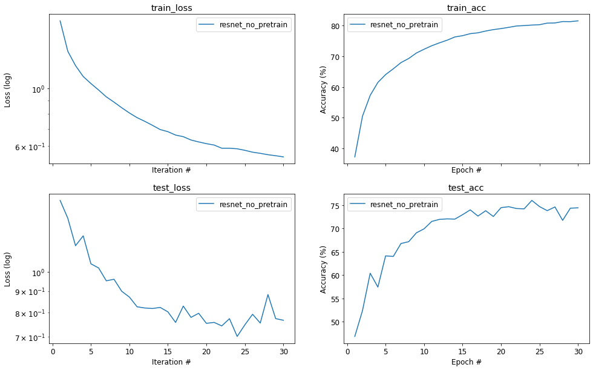

```python
plot_exp_results('exp5*.json') # plot your experiments results
```

**Answer in your Report:** What was ResNet50 accuracy and loss? Is it overfit/underfit/well-fit the data? Summarize this section results in your report.

### 6. Pretrained ResNet50

Now use ResNet50 with pretraining (use pretrained=True when you load the model) and run this model on cifar 10. you will need to change the last linear layer. Tip: `model.fc = nn.Linear(2048, 10)`. you may want to use lower learning rate.

```python
import torchvision.models as models
# Use meaningful names!
# ====== YOUR CODE: ======
# these parameters dont matter, we changed the model inside the experiment file
experiments.run_experiment(f'l2_0.1',
                               seed=seed,
                               bs_train=50,
                               batches=10000,
                               epochs=30,
                               early_stopping=4,
                               reg=1e-3,
                               lr=1e-3,
                               filters_per_layer=[128],
                               layers_per_block=4,
                               pool_every=2,
                               hidden_dims=[200, 200],
                               ycn=True)
# ========================
```

[output not shown]

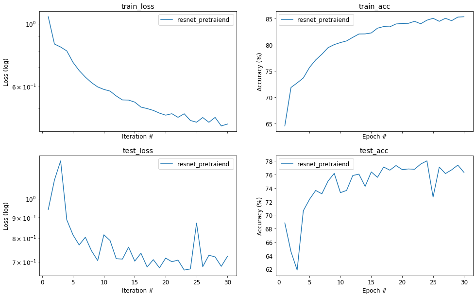

```python
plot_exp_results('exp6*.json') # plot your experiments results
```

**Answer in your Report:** What was the pretrained ResNet50 accuracy and loss? Is it overfit/underfit/well-fit the data? Has it got better accuracy than the non-pretrained ResNet? Summarize this section results in your report.

### 5. Extra Points - Exploring additional architectures

Try more achitectures. You may want to read this: https://pytorch.org/vision/stable/models.html You can choose if to use the pretrained version or not.

```python
import torchvision.models as models
# Use meaningful names!
# ====== YOUR CODE: ======
# these parameters dont matter, we changed the model inside the experiment file
experiments.run_experiment(f'l2_0.1',
                               seed=seed,
                               bs_train=50,
                               batches=10000,
                               epochs=30,
                               early_stopping=4,
                               reg=1e-3,
                               lr=1e-3,
                               filters_per_layer=[128],
                               layers_per_block=4,
                               pool_every=2,
                               hidden_dims=[200, 200],
                               ycn=True)
# ========================
```

[output not shown]

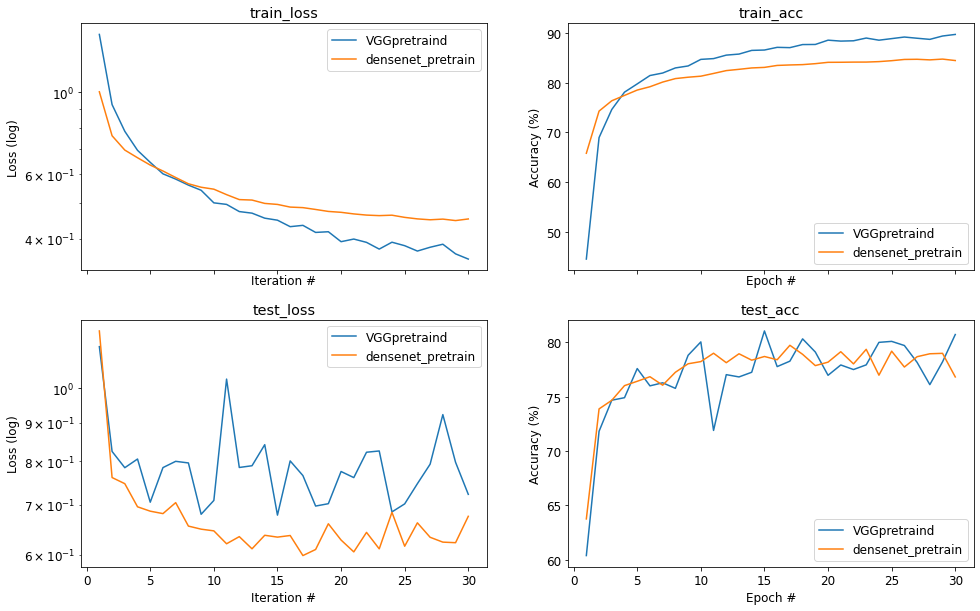

```python
plot_exp_results('exp7*.json') # plot your experiments results
```

**Answer in your Report:** What was the best pretrained architecture? Is it overfit/underfit/well fit the data? Summarize this section results in your report.

## Project Summary

**Answer in your Report:** Write a short summerization of your attempts. What worked for you? which architecture and hyperparameters led to the best preformance?

```python
%%shell
jupyter nbconvert
--to html "/content/tests"
```

[output not shown]

[output cut: 106 more lines]

[output not shown]

[output not shown]